# Co-clustering example

David Beley, Boubacar Sow

2019-02-14

Dans ce rapport nous présentons notre paquet R **coclust**, permettant d’effectuer un co-clustering gaussien à modèle de blocs latents.

## Préparation de l’environnement

```r
library(coclust)
library(blockcluster)
library(printr)
data("gaussiandata")
```

**coclust** est notre paquet, implémentant un co-clustering gaussien à blocs latent.

**blockcluster** est le paquet de co-clustering qui servira de comparaison.

**printr** est un paquet permettant l’impression des pages d’aide dans un rapport rmarkdown.

# Paquet coclust

Notre paquet contient trois fonctions : * lbvem * icl * plot_coclust

## Fonction lbvem

| lbvem | R Documentation |
| --- | --- |

## Co-clustering main function using gaussian LBVEM

### Description

Co-clustering main function using gaussian LBVEM

### Usage

```r
lbvem(data, nbcoclust, init = 10)
```

### Arguments

| `data` | continuous data (matrix or dataframe) |
| --- | --- |
| `nbcoclust` | 2d vector specifying the number of clusters (row and column respectively) |
| `init` | number of iterations for the initialization |

### Value

a coclust result object

### Examples

```r
library(coclust)
library(blockcluster)
data("gaussiandata")
lbvem(gaussiandata, c(3, 3), init=50)
```

## Fonction icl

| icl | R Documentation |
| --- | --- |

## ICL criteria

### Description

ICL criteria

### Usage

```r
icl(data, z, w, pi, rho, mu, sigma)
```

### Arguments

| `data` | data object from lbvem function |
| --- | --- |
| `z` | z object from lbvem function |
| `w` | w object from lbvem function |
| `pi` | pi object from lbvem function |
| `rho` | rho object from lbvem function |
| `mu` | mu object from lbvem function |
| `sigma` | sigma object from lbvem function |

### Value

ICL value

### Examples

```r
library(coclust)
library(blockcluster)
data("gaussiandata")
res <- lbvem(gaussiandata, nbcoclust = c(3, 3), init = 50)
icl(res$data, res$z, res$w, res$pi, res$rho, res$mu, res$sigma)
```

## Fonction plot_coclust

| plot_coclust | R Documentation |
| --- | --- |

## plot the output of a coclust result object

### Description

plot the output of a coclust result object

### Usage

```r
plot_coclust(res)
```

### Arguments

| `res` | coclust result object |
| --- | --- |

### Examples

```r
library(coclust)
library(blockcluster)
data("gaussiandata")
res <- lbvem(gaussiandata, nbcoclust = c(3, 3), init = 50)
plot_coclust(res)
```

## Co-clustering

Nous effectuons un co-clustering avec la fonction lbvem sur les données gaussiandata du package blockcluster.

```r
res <- lbvem(gaussiandata, nbcoclust = c(4, 3), init = 10)
```

```
#> [1] "ICL :  -185541.026116364"
#> [1] "ICL :  -185862.77398272"
```

Notre fonction lbvem effectue un co-clustering gaussien à modèle latent par blocs. Pour trouver les paramètres de la log-likelihood, nous avons implémenté l’algorithme VEM (Variational Expected Maximisation). Nous avons également implémenté le critère de convergence ICL (Integrated Completed Likelihood), il permet de choisir le modèle pertinent, et le nombre de composantes du modèle de mélange gaussien.

Pour le critère de convergence de lbvem nous avons utilisé deux méthodes :

- pour sortir de l’algorithme VEM nous vérifions que les matrices des Paramètres estimés (uniquement la moyenne dans notre cas) ne se modifie plus vraiment (écart entre l’ancienne matrice et la nouvelle < 10)
- nous répéterons jusqu’à ce que le critère ICL ne bouge plus (écart entre l’ancien et le nouveau < 1) ou ne décroît plus

L’initialisation de lbvem s’est faite avec kmeans clustering par lignes et colonnes.

Pour les jeux de données que nous avons testés, nous observons que dans certains cas, nous n’obtenons pas le même nombre clusters initiales et finales, les clusters se vident.

## ICL

```r
res$icl
```

```
#>        V1
#> -185862.8
```

## Représentation graphique

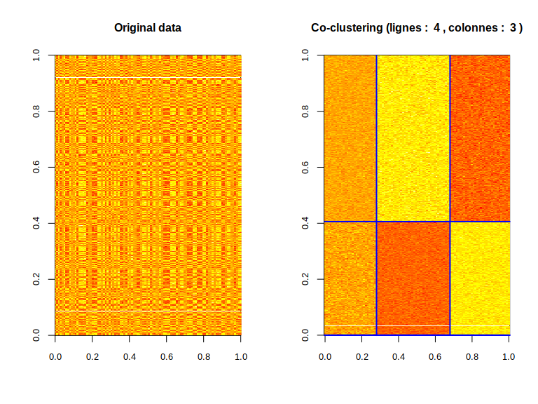

```r
plot_coclust(res)
```

À gauche se trouve les données originales, à droite les données avec le partitionnement trouvé par notre fonction de co-clustering.

# Blockcluster package

## Co-clustering

```r
out <- coclusterContinuous(as.matrix(gaussiandata), nbcocluster = c(4, 3))
```

```
#> Co-Clustering successfully terminated!
```

## ICL

```r
summary(out)
```

```
#> Model Family : Gaussian Latent block model
#> Model Name : pik_rhol_sigma2kl
#> Co-Clustering Type : Unsupervised
#> ICL value:  -184852.7
#>
#> Model Parameters..
#>
#> Class Mean:
#>            [,1]       [,2]       [,3]
#> [1,] -0.2185440   9.988018  -9.894256
#> [2,]  0.1940780   9.879761 -10.055736
#> [3,] -0.1035334 -10.061110  10.028324
#> [4,]  0.1058112  -9.872412  10.034770
#>
#> Class Variance:
#>          [,1]      [,2]      [,3]
#> [1,] 20.62305 10.567958  9.780261
#> [2,] 20.88135  9.141704 10.254419
#> [3,]  9.76235 19.992827 21.038561
#> [4,] 10.22784 19.906952 18.554514
#>
#> Row proportions:  0.25 0.25 0.25 0.25
#> Column proportions:  0.28 0.32 0.4
#> Pseudo-likelihood:  -184699.6
```

On retrouve une valeur de l’ICL proche de la valeur trouvée par notre fonction.

## Représentation graphique

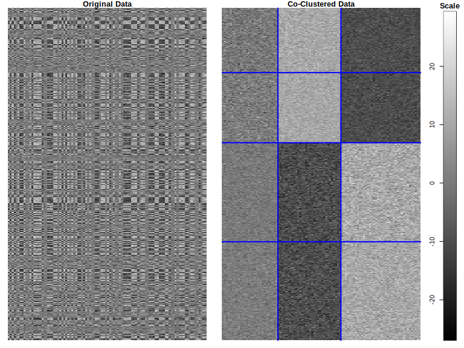

```r
plot(out)
```

# Test sur iris

## Préparation des données

```r
iris2 <- subset(iris, select=-Species)
```

## Co-clustering

```r
res_iris <- lbvem(iris2, c(4, 2), 50)
```

```
#> [1] "ICL :  -511.250638042744"
#> [1] "ICL :  -798.548330880802"
```

## ICL

```r
res_iris$icl
```

```
#> [1] -798.5483
```

## Représentation graphique

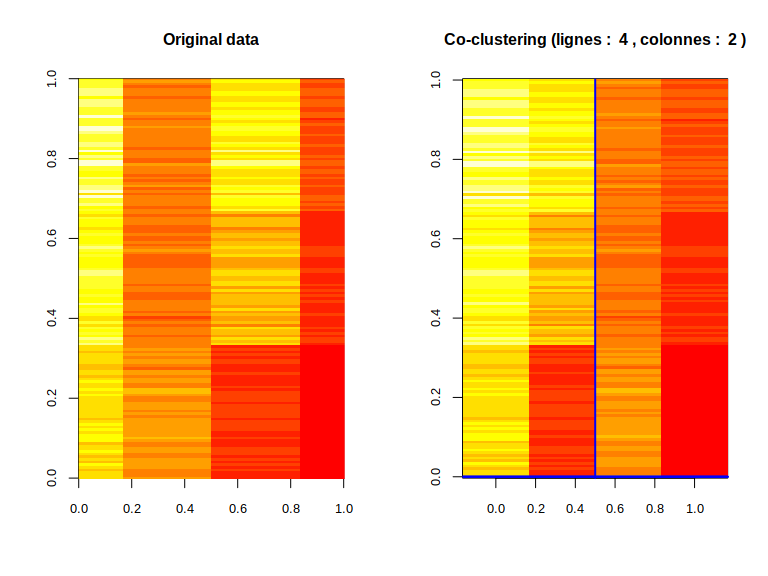

```r
plot_coclust(res_iris)
```